# TRACTION Meeting

Lauren Wilner

30 March, 2023

*Per Phil et al’s paper: PA bouts were defined as time intervals having accelerometer counts > 500 counts per 30 s epoch (cpe) for at least 7 min, allowing for up to 2 min of epochs below that threshold during the 7 min interval.*

*Per WalkboutR package decisions: We have decided that we will consider something a bout as long as it is at least 5 minutes.* *NOTE: all of this is done presuming that the accelerometry package processed the accelerometry data the same way/the correct way! I cannot use the package right now and thus cannot confirm this*

### Section 1: Overall Concordance

In order to evaluate overall concordance between the results in Phil/Bumjoon’s analysis and the WalkboutR package, we used a fuzzy merge that allowed for a 5 minute difference in bout start/end time in order for the merge to be successful. As such, if the start/end times for 2 bouts were more than 5 minutes apart, the bout identified by Phil/Bumjoon and the bout identified by WalkboutR were not matched.

| Identified Bouts | Count | Percent |
| --- | --- | --- |
| **Walk Bouts** |  |  |
| Walk bout identified by all | 4278 |  |
| **Phil/Bumjoon Paper** |  |  |
| Walk bout identified by Phil/Bumjoon (no comparable walkbout identified by WalkboutR) | 6020 |  |
| Walk bout identified by Phil/Bumjoon, Non-walk bout identified by the WalkboutR package | 0 | 0.00 |
| Walk bout identified by Phil/Bumjoon, Non-walk bout identified by the WalkboutR package due to speed | 410 | 6.81 |
| Walk bout identified by Phil/Bumjoon, Non-walk bout identified by the WalkboutR package due to dwell | 116 | 1.93 |
| Walk bout identified by Phil/Bumjoon, Non-walk bout identified by the WalkboutR package (other) | 0 | 0.00 |
| **Our code** |  |  |
| Walk bout identified by the WalkboutR package (no comparable walkbout identified by Phil/Bumjoon) | 5597 |  |
| Walk bout identified by the WalkboutR package, Non-walk bout identified by Phil/Bumjoon | 0 | 0.00 |
| Walk bout identified by the WalkboutR package, Non-walk bout identified by Phil/Bumjoon due to speed | 175 | 3.13 |
| Walk bout identified by the WalkboutR package, Non-walk bout identified by Phil/Bumjoon due to dwell | 10 | 0.18 |
| Walk bout identified by the WalkboutR package, Non-walk bout identified by Phil/Bumjoon code (other) | 0 | 0.00 |

### Section 2: Bouts that differ due to cumulative versus consecutive low/inactive time counting

**ID 10902186**: WalkboutR starts a bout later than Phil/Bumjoon becuase there are 4 epochs of low/inactivity, causing WalkboutR to try to start a bout at 7:14a, having the potential bout end 2.5 minutes later, then actually starting at 7:17a.

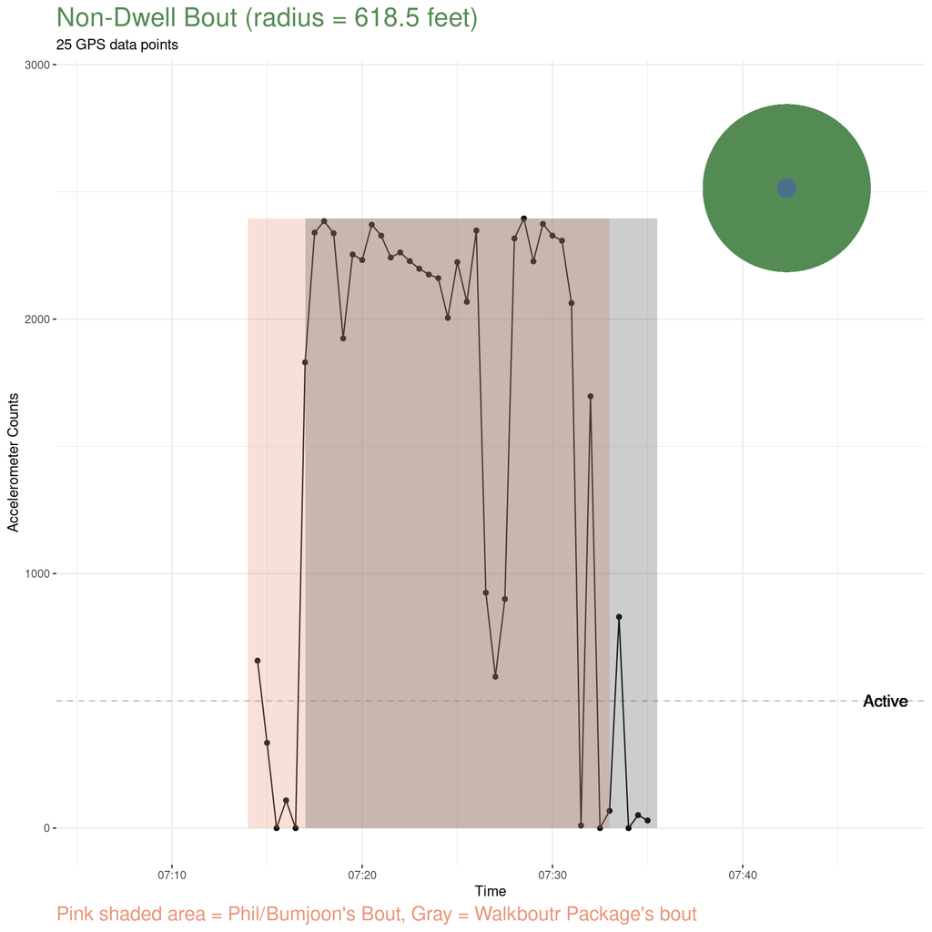

**ID 10704259**: WalkboutR starts a bout at 14:22:00 on an active epoch. WalkboutR ends it at 14:33:30 when there are 4+ periods of inactivity. Phil ends at the same point for the same reason. Phil starts his bout on an active epoch at 14:25 (I believe) because he had been trying to start bouts before that and hitting his threshold of cumulative low/inactivity. This difference can be attributed to a difference in our implementation of cumulative vs consecutive thresholds for ending a bout and thus for where we begin bouts based on where other bouts end.

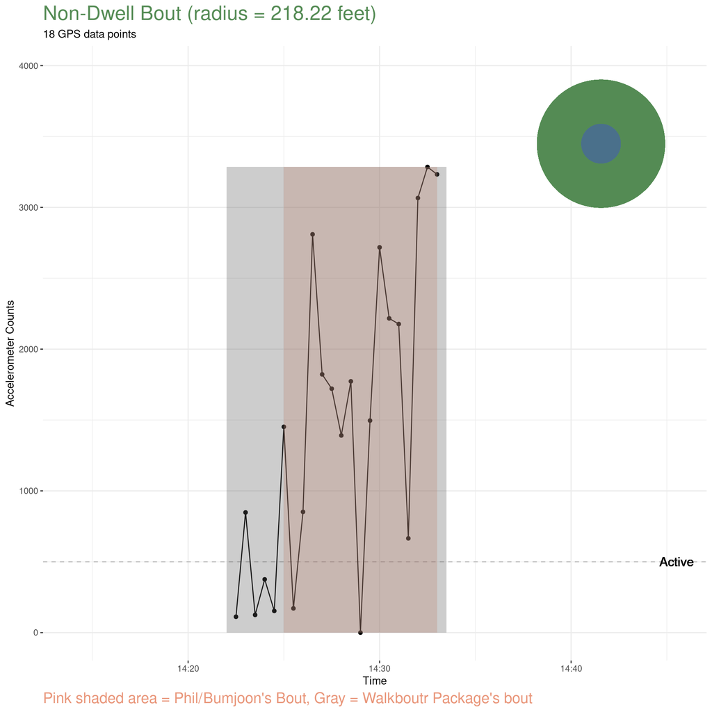

**ID 14427353**: Another example similar to the one above.

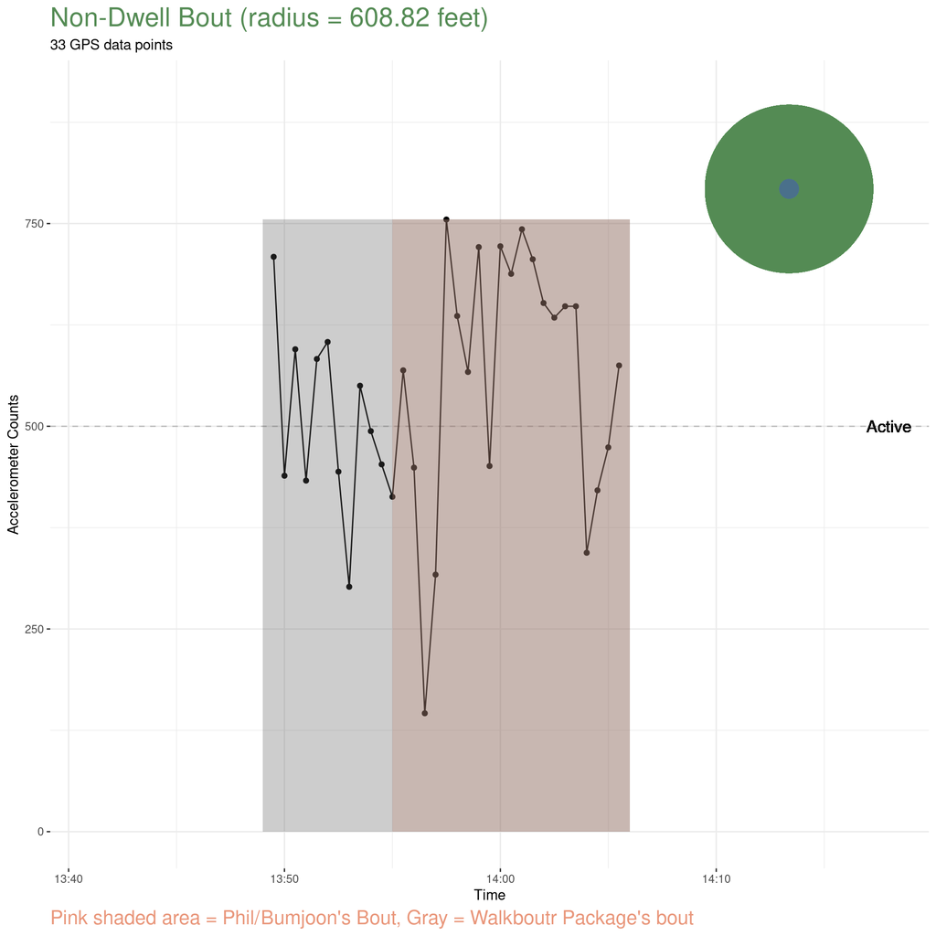

### Section 2: Differences based on speed

*PA bouts occurring within a single location were considered as “dwells,” which were considered non-walking by definition. Identifying a dwell bout was accomplished by (1) calculating the sum of distances from each point to all other points within the bout; (2) selecting points having sum distance below the 95th percentile of the sum distances of all points in the bout; (3) generating a minimum bounding circle fully containing the selected points; (4) finally obtaining the circle’s radius. Bouts with radii <= 66 ft were considered as dwell bouts. Because some non-dwell bouts with few GPS observations were likely to have radii <= 66 ft, dwell bouts were defined as having >=10 GPS points.*

| Speed Metric Equivalencies | Count | Percent of Total |
| --- | --- | --- |
| mean.p = mean.walkboutr | 1151 | 48.53 |
| mean.p = median.walkboutr | 2 | 0.08 |
| mean.p = median.walkboutr = mean.walkboutr | 340 | 14.33 |
| no speed metrics are equivalent | 879 | 37.05 |

| Walk Type (WalkboutR package) | Walk Type (Phil/Bumjoon code) | Speed Metric Equivalencies | Count | Percent of Total |
| --- | --- | --- | --- | --- |
| nonwalk2_gps_dwell | nonwalk2_gps_speed | mean.p = mean.walkboutr | 11 | 0.46 |
| nonwalk2_gps_dwell | walk1_gps | mean.p = mean.walkboutr | 68 | 2.87 |
| nonwalk2_gps_speed | nonwalk2_gps_dwell | mean.p = mean.walkboutr | 690 | 29.09 |
| nonwalk2_gps_speed | walk1_gps | mean.p = mean.walkboutr | 258 | 10.88 |
| walk1_gps | nonwalk2_gps_speed | mean.p = mean.walkboutr | 124 | 5.23 |
| nonwalk2_gps_speed | nonwalk2_gps_dwell | mean.p = median.walkboutr | 2 | 0.08 |
| nonwalk2_gps_dwell | walk1_gps | mean.p = median.walkboutr = mean.walkboutr | 10 | 0.42 |
| nonwalk2_gps_speed | nonwalk2_gps_dwell | mean.p = median.walkboutr = mean.walkboutr | 328 | 13.83 |
| nonwalk2_gps_speed | walk1_gps | mean.p = median.walkboutr = mean.walkboutr | 2 | 0.08 |
| nonwalk1_acc | walk1_gps | no speed metrics are equivalent | 1 | 0.04 |
| nonwalk2_gps_dwell | nonwalk2_gps_speed | no speed metrics are equivalent | 1 | 0.04 |
| nonwalk2_gps_dwell | walk1_gps | no speed metrics are equivalent | 38 | 1.60 |
| nonwalk2_gps_speed | nonwalk2_gps_dwell | no speed metrics are equivalent | 628 | 26.48 |
| nonwalk2_gps_speed | walk1_gps | no speed metrics are equivalent | 150 | 6.32 |
| walk1_gps | nonwalk2_gps_dwell | no speed metrics are equivalent | 10 | 0.42 |
| walk1_gps | nonwalk2_gps_speed | no speed metrics are equivalent | 51 | 2.15 |

#### Code Appendix

```r
knitr::opts_chunk$set(echo = TRUE)
library(tidyverse)
library(lubridate)
library(knitr)
library(ggforce)
library(lwgeom)
library(sf)
library(geosphere)
library(measurements)
library(patchwork)
library(kableExtra)

low_active_thresh <- 500
gps_thresh <- 66

# Plotting function
source("~/repos/rwalkbout/R/bout_plot.R")
source("~/repos/rwalkbout/R/concordance.R")
source("~/repos/rwalkbout/R/get_speed_table.R")



merge_data <- get_merge_data()
concordance <- get_concordance_table(merge_data)
kable(concordance, booktabs = T, escape = F) %>%
  add_indent(c(3:6, 8:11)) %>%
  group_rows("Walk Bouts", 1, 1) %>%
  group_rows("Phil/Bumjoon Paper", 2,6) %>%
  group_rows("Our code", 7,11) %>%
  gsub("NA", " ", .)

id <- 10902186
phil_start_time <- ymd_hms("2008-09-09 07:14:00")
phil_end_time <- ymd_hms("2008-09-09 07:33:00")
w_start_time <- ymd_hms("2008-09-09 07:17:00")
w_end_time <- ymd_hms("2008-09-09 07:35:30")
phil_bout_duration <- 19.5

df <- read.csv(paste0("~/walkbout_csvs/", id, "_gps_acc.csv"))

table <- df %>%
  mutate(epoch_time = ymd_hms(epoch_time)) %>%
  filter(epoch_time > min(phil_start_time, w_start_time)) %>%
  filter(epoch_time < max(phil_end_time, w_end_time)) %>%
  select("epoch_time", "Axis1_epochSum", "Activity", "bout_label", "gps_inlier",
         "epoch_time", "LATITUDE", "LONGITUDE", "Point_circle_area", "Point_radius", "incomplete_GPS")
bout <- table %>% filter(!(is.na(bout_label)))
bout <- unique(bout$bout_label)
bout_plot(id, gps_thresh, low_active_thresh, table)
# kable(table %>% filter(!is.na(bout_label)))

id <- 10704259
phil_start_time <- ymd_hms("2008-09-10 14:25:00")
phil_end_time <- ymd_hms("2008-09-10 14:33:00")
w_start_time <- ymd_hms("2008-09-10 14:22:00")
w_end_time <- ymd_hms("2008-09-10 14:33:30")
phil_bout_duration <- 9

df <- read.csv(paste0("~/walkbout_csvs/", id, "_gps_acc.csv"))

table <- df %>%
  mutate(epoch_time = ymd_hms(epoch_time)) %>%
  filter(epoch_time > min(phil_start_time, w_start_time)) %>%
  filter(epoch_time < max(phil_end_time, w_end_time)) %>%
  select("epoch_time", "Axis1_epochSum", "Activity", "bout_label", "gps_inlier",
         "epoch_time", "LATITUDE", "LONGITUDE", "Point_circle_area", "Point_radius", "incomplete_GPS")
bout <- table %>% filter(!(is.na(bout_label)))
bout <- unique(bout$bout_label)
bout_plot(id, gps_thresh, low_active_thresh, table)
# kable(table %>% filter(!is.na(bout_label)))

id <- 14427353
phil_start_time <- ymd_hms("2009-05-29 13:55:00")
phil_end_time <- ymd_hms("2009-05-29 14:06:00")
w_start_time <- ymd_hms("2009-05-29 13:49:00")
w_end_time <- ymd_hms("2009-05-29 14:06:00")
phil_bout_duration <- 11

df <- read.csv(paste0("~/walkbout_csvs/", id, "_gps_acc.csv"))

table <- df %>%
  mutate(epoch_time = ymd_hms(epoch_time)) %>%
  filter(epoch_time > min(phil_start_time, w_start_time)) %>%
  filter(epoch_time < max(phil_end_time, w_end_time)) %>%
  select("epoch_time", "Axis1_epochSum", "Activity", "bout_label", "gps_inlier",
         "epoch_time", "LATITUDE", "LONGITUDE", "Point_circle_area", "Point_radius", "incomplete_GPS")
bout <- table %>% filter(!(is.na(bout_label)))
bout <- unique(bout$bout_label)
bout_plot(id, gps_thresh, low_active_thresh, table)
# kable(table %>% filter(!is.na(bout_label)))

speed_table <- get_speed_table(merge_data)
speed_table_small <- speed_table %>%
  group_by(speed_flag) %>%
  summarise(count = sum(count),
            percent = sum(percent)) %>%
  arrange(percent)
bar <- ggplot(data = speed_table_small, aes(x = reorder(speed_flag, -percent), y = percent, fill = percent)) +
  geom_bar(stat="identity") +
  theme(axis.text.x = element_text(angle = 15)) +
  labs(xlab = "Speed Metric Equivalencies",
       ylab = "Percent of Total",
       Title = "Distribution of Speed Differences")

speed_table_small <- speed_table_small %>%
  arrange(speed_flag) %>%
  rename("Speed Metric Equivalencies" = speed_flag, "Count" = count, "Percent of Total" = percent)

speed_table <- speed_table %>%
  arrange(speed_flag) %>%
  rename("Walk Type (WalkboutR package)" = walk_type.w, "Walk Type (Phil/Bumjoon code)" = walk_type.p,
         "Speed Metric Equivalencies" = speed_flag, "Count" = count, "Percent of Total" = percent)

kable(speed_table_small) %>% kable_styling()
kable(speed_table) %>% kable_styling()
```